# Body Area Network technologies for predictive medicine in ciliopathy use-cases

### 6.4.2 Examining the Data

Firstly, we perform the distribution of each phenotype:

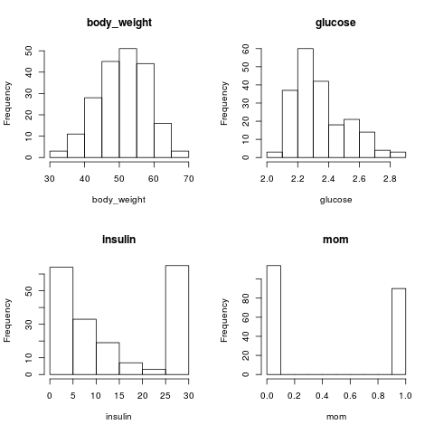

Fig. Histograms of phenotypes

While body weight looks relatively normally distributed, glucose and insulin have obviously non-normal distributions. Before proceeding with the analysis we mean centre and normalize all phenotypes. After normalization, only insulin still has a ceiling effect, which cannot be removed by normalization because rank cannot be determined among equal values. Then we examen the Q-Q plots of pairs of phenotypes for reveal phenotyping errors and other pathologies.

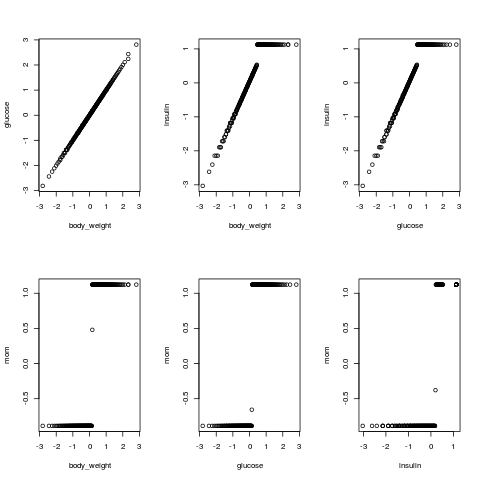

Fig. QQ-plots for pairs of phenotypes.

Here the ceiling effect is visible in the insulin measurement and this cannot be removed through normalization. Moreover, the distribution is more similar to those of the other phenotypes than before normalization. Knowing that this ceiling effect we can simply remove insulin from the analysis, but here we will it rest in data object.

### 6.4.3 Phenotype Selection

This method relies on the selection of two or more phenotypes that have common genetic factors but are not identical across all individuals. Such phenotypes may describe multiple aspects of a single complex trait, (in this case - obesity ), and may encompass a combination of molecular phenotypes, such as plasma glucose levels, and phenotypes, such as body weight, that are measured at the organismal level. The central assumption of this method is that different genetic interactions found for a single gene pair in the context of different phenotypes represent multiple manifestations of a single underlying gene network. By measuring the interactions between genetic variants in different contexts we can gain a clearer picture of the network underlying statistical epistasis [8]. By examining the correlations between phenotypes, we can see that the phenotypes measured in this experiment are correlated, but not identical across all individuals.

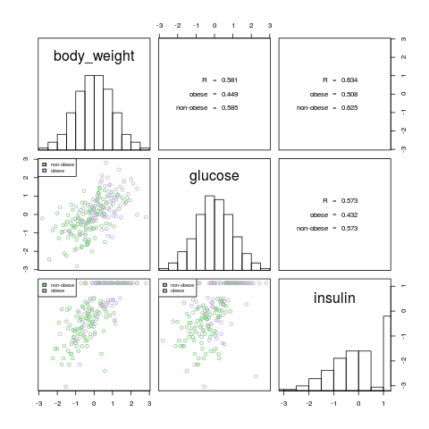

Fig. Correlations between phenotypes

### 6.4.4 Singular value decomposition of phenotype matrix

Prior to calculating the linear regression models, we decomposed the phenotypes via singular value decomposition (SVD) into their prin- cipal components, called eigentraits (ETs) [10]. This step decorrelates the phenotypes, reorganizing phenotypic signals into orthogonal, com- posite phenotypes. This procedure potentially concentrates genetic associations, in that variants with weak associations to multiple orig- inal phenotypes often exhibit strong association to one ET. Although the final CAPE-derived model will be recast in terms of the original phenotypes, this provides enhanced detection of candidate loci for interaction analysis.

Before the selection of eigentraits, the eigentraits should be examined

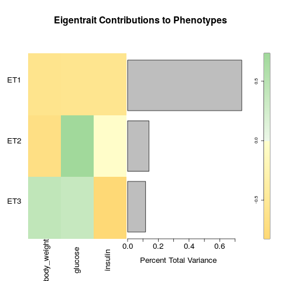

### 6.4.5 Single-Variant Scan

Once the eigentraits for the analysis have been selected, the single-locus scan is run to investigate how individual markers are associated with each eigentrait. This scan performs a linear regression at each marker. Single-Variant Scan can be used as pre-processing step for filtering variants and to choose those that will be incuded in the pair scan. It is useful, taking into account that the number of possible variant pairs may be too large to test exhaustively in case the large data sets. And it can helps to avoid obscuring interactions by large main effects - variants with large main-effects can be used as covariates in the pair scan. The single-marker scan currently does not support markers on sex chromosomes. Because the X chromosome is hemizygous in males, sex differences in phenotype can lead to false associations, and markers on this chromosome require special consideration [39].

#### 6.4.5.1 Single-Locus Effects on Phenotypes

We used linear regression to determine the association of each locus with each phenotype.

The results of the single variant scan can be visualized:

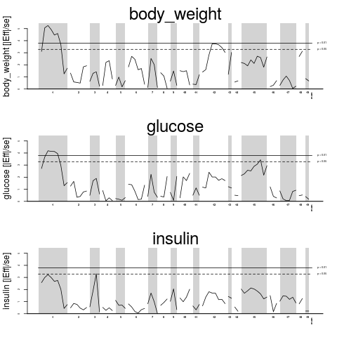

Fig. Single-locus associations with phenotypes

For better comparison of effects between phenotypes we present heatmap which demonstrate the effects of each regression on each phenotype:

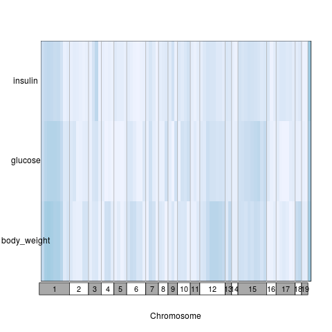

Fig. Heatmap of Single-locus associations with phenotypes

#### 6.4.5.2 Single-Locus Effects on Eigentraits

Above we decomposed the normalized, mean-centered phenotypes into eigentraits and described them. As it is seen on figure below single-locus associations with each ET detected multiple QTL:

The results of the single variant scan can be visualized

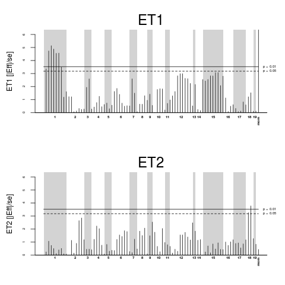

Fig. Single-locus scan with eigentraits

In this figure the t-statistic of each marker is plotted as a vertical line. Results for both eigentraits are shown here as ET1 and ET2, and chromosome numbers are written along the x axis. In this example we will not filter the markers and use all markers in the pairwise scan. Since ET are linear combinations of traits, each QTL indicates a potentially pleiotropic association with varying effect strengths on each trait. For example, data for body weight and glucose had overlapping QTL on Chr 1. These phenotypes also contributed substantially to ET1, and there was a corresponding significant QTL for ET1 on Chr 1 representing the common QTL.

### 6.4.6 Pairwise Scan

The purpose of the pairwise scan is to find interactions, or epistasis, between variants. The epistatic models are then combined across phenotypes or eigentraits to infer a network that takes data from all eigentraits into account. But before running the pair scan, it is important that we reduce the genetic matrix to only markers that are linearly independent of one another. Some of the markers used were tightly linked to one another. So we need calculate the correlation between all pairs of markers. High Pearson correlation between markers indicates that the individual markers supply redundant information and can lead to false-positive interactions. To address this problem, we will filter the marker pairs by removing all highly correlated pairs from consideration using a Pearson correlation cutoff of r ≥ 0.75.

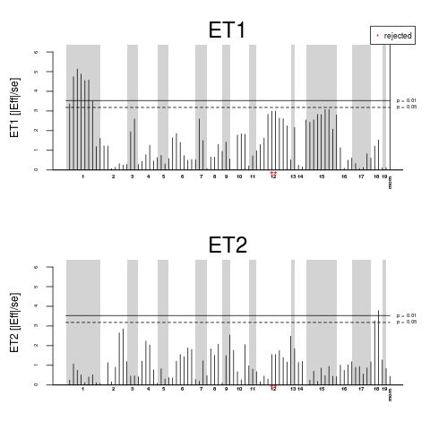

Fig. The results of the markers selected for pairscan

In figure above we can see the locations of discarded markers, which markers have been selected for the pair scan and which have been rejected. A total of 2 marker pairs (56, 57) were eliminated in this filtering step. After ensuring that all markers are linearly independent and thresholded satisfactorily, the pairscan can be run. In fact pairscans are performed for each ET by multivariate linear regression, with an intercept, covariates, main effects, and interaction term for each pair of markers. Interaction (epistasis) coefficients from each ET can be plotted as shown in the following pdf-file:

[figure not shown]

Fig. The results of the pair scan

Click here to download the big picture of the results of the pairwise scan.

This plot shows the resulting t-statistic for each pair of markers for ET1. Symmetric matrices of all marker pair interaction terms are displayed in matrix form, with gray and white bars along the axes to mark chromosome boundaries.Gray and white bars show the boundaries of the chromosomes. 82 markers were selected for the pairscan. This makes 3321 possible pairs.

### 6.4.7 Detection of Interactions

From the pairwise the coefficients regression are then reparametrized to give direct influence coefficients, describing how each marker either enhances or suppresses the activity of each other marker. First two new parameters (δ 1 and δ 2 ) are defined in terms of the interaction coefficients from the pairwise regression. δ 1 can be thought of as the additional genetic activity of the variant near marker 1 when the variant near marker 2 is present. The δ terms are independent of phenotype and together completely describe the interaction term. They can be interpreted as the extent to which each marker influences the effect of the other on the phenotypes. For example, a negative δ 2 indicates that the presence of variant 2 suppresses the effect of variant 1 on the ETs. The δ terms are related to the main effects and interaction effects. In the picture below we present:

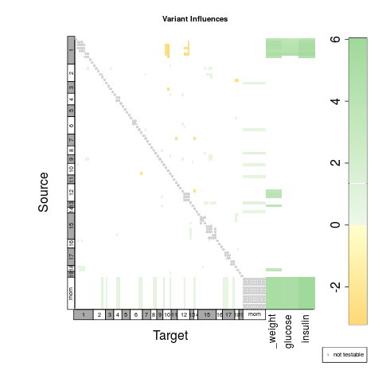

Fig. Plot Variant Influences

In the figure above all non-significant interactions are colored white.

As an example, present first 7 rows of the table of significant influences:

| Source | Target | Effect | SE | X.Effect..SE | P_empirical | qval |
| --- | --- | --- | --- | --- | --- | --- |
| mom | insulin | 0.5492437 | 0.0911159 | 6.027969 | 0 | < 0.00296 |
| D1Mit76 | insulin | 0.8006307 | 0.1378770 | 5.806849 | 0 | < 0.00296 |
| D1Mit123 | insulin | 0.7471561 | 0.1392996 | 5.363661 | 0 | < 0.00296 |
| D1Mit411 | insulin | 0.7429545 | 0.1389041 | 5.348688 | 0 | < 0.00296 |
| mom | body_weight | 0.5686825 | 0.1085399 | 5.239388 | 0 | < 0.00296 |
| D1Mit213 | insulin | 0.7201700 | 0.1403843 | 5.129990 | 0 | < 0.00296 |
| mom | glucose | 0.5539787 | 0.1082084 | 5.119552 | 0 | < 0.00296 |

### 6.4.8 Results

The plot of network is demonstrated below. It presents the chromosomes in a circle and shows interactions as arrows between regions on chromosomes:

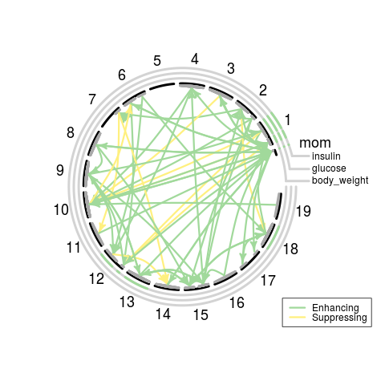

Fig. Plot Network

# 7 WBAN data security and privacy aspects

The main points in which security must be applied within WBAN are: On sensors attached in, on or around user’s body. On personal servers (where aggregated information is kept and to be sent out side for further processing). On Communication channels & various entry/exit points or gateways. On Internet (to connect medical community outside the WBAN). On Devices used by Clinicians or medical helpers.

A lot of research has been taken place and still in progress to solve this safety problem within WBANs, including:

## 7.2 Multidisciplinary approaches used to develop secure WBANs in healthcare.

Since WBANs are directly related to human health, so different human body generated or contained values/information can be made used to grow security within systems. By following above idea, robustness property of human body is used as an inspiration [32] which is evolved from biology to develop secure systems. An approach to secure WBAN using BIO-Inspiration developed by Rathore et al. is revolutionary idea in recent scenario. In this research security is implemented by using human immune system as it base and inspiration along with machine learning techniques have been applied here. Here malicious nodes are detected by machine learning module. Antigen and antibody concept of human immune system is used as a different module for removal of malicious nodes from communication network. According to another research new improved encryption mechanisms are developed on the basis of two concepts- DNA computation and Chaos Theory [33]. It targets secure data communication by using a concept- only encrypted information will be transmitted. DNA based cryptography is not a new method but doing this along with chaos theory of non-linear mathematical model brings a broad and unpredictable encryption scheme in to picture. Unauthorized user will feel this chaotic encrypted data as a noise. So chaos is used as a key generator and it proved as a strong pseudorandom generator. By this concept safe, collision-free and efficient MAC protocol could be developed here.

## 7.3 Protocol-redesigning and development based mechanism to implement security in WBANs in healthcare.

# 8 Supporting information

`Table 1`

**Details of the health trackers**

List of health trackers. Click on name of health tracker for to go to corresponding site Internet.

(XLSX)

Click here for additional data file.

Download file [here](https://drive.google.com/open?id=0BwBJmLQ-6h-bRHVMOTFvR0ZkVVE)

# 9 Data availability

All relevant data are within the paper and its Supporting information files.

# 10 References

1. www.obesite-sante.com
2. Atkinson RL. Etiologies of Obesity. In The Management of Eating Disorders and Obesity, Second Edition. Edited by: D. J. Goldstein. Humana Press Inc., Totowa, NJ. 2005.
3. Stenvinkel P. Obesity–a disease with many aetiologies disguised in the same oversized phenotype: has the overeating theory failed? Nephrol Dial Transplant. 2015.
4. Xue J, Ideraabdullah FY. An assessment of molecular pathways of obesity susceptible to nutrient, toxicant and genetically induced epigenetic perturbation. J Nutr Biochem. 2016.
5. Lee EB, Mattson MP. The neuropathology of obesity: insights from human disease. Acta Neuropathol. 2014 127:3-28.
6. Chennen K, Scerbo MJ, Dollfus H, Poch O, Marion V. Bardet-Biedl syndrome: cilia and obesity - from genes to integrative approaches. Med Sci (Paris). 2014.
7. Feuillan PP, Ng D, Han JC, Sapp JC, Wetsch K, Spaulding E, Zheng YC, Caruso RC, Brooks BP, Johnston JJ, Yanovski JA, Biesecker LG. Patients with Bardet-Biedl syndrome have hyperleptinemia suggestive of leptin resistance. J Clin Endocrinol Metab. 2011.
8. Carter, G. W., Hays, M., Sherman, A., and Galitski. Use of pleiotropy to model genetic interactions in a population. PLoS genetics, 2012.
9. Reifsnyder, P. C. Maternal Environment and Genotype Interact to Establish Diabesity in Mice. Genome Research. 2002.
10. Alter O, Brown PO, Botstein D. Singular value decomposition for genome-wide expression data processing and modeling. Proc Natl Acad Sci. 2000.
11. Darabos, CHRISTIAN, Harmon, SAMANTHA H, Moore, JASON H: Using the bipartite human phenotype network to reveal pleiotropy and epistasis beyond the gene. Pacific Symposium on Biocomputing. Pacific Symposium on Biocomputing Page: 188, 2014.
12. VIVEK M Philip, Anna L Tyler, and Gregory W Carter. Dissection of complex gene expression using the combined analysis of pleiotropy and epistasis. In Paci c Symposium on Biocomputing. Paci c Symposium on Biocomputing, volume 19, p. 212. World Scienti c, 2014.
13. Bell CG, Walley AJ, Froguel P. The genetics of human obesity. Nat Rev Genet. 2005.
14. https://cran.r-project.org
15. J. A. Gliner, N. Leech, and G. Morgan, “Problems with null hypothesis significance testing (NHST): what do the textbooks say?” Journal of Experimental Education, vol. 71, no. 1, pp. 83–92, 2002.
16. L. S. Erdreich and E. T. Lee, “Use of relative operating characteristic analysis in epidemiology. A method for dealing with subjective judgement,” American Journal of Epidemiology, vol.114, no. 5, pp. 649–662, 1981.
17. T. Hastie, R. Tibshirani, and J. Friedman, The Elements of Statistical Learning, Springer, Berlin, Germany, 2nd edition,
19. Klonoff, D.C.: Personalized medicine for diabetes. J. Diabetes Sci. Technol. 2, 2008.
20. Anthimopoulos, M.M., Gianola, L., Scarnato, L., Diem, P., Mougiakakou, S.G.: A food recognition system for diabetic patients based on an optimized bag-of-features model. IEEE J. Biomed. Heal. Inf. 18, 2014.
21. Xiaochen Huang, Emmanuel Agu: A Speech-Based Mobile App for Restaurant Order Recognition and Low-Burden Diet Tracking. ICSH 2015.
22. Van Remoortel H, Giavedoni S, Raste Y, Burtin C, Louvaris Z, Gimeno-Santos E, et al. Validity of activity monitors in health and chronic disease: a systematic review. Int J Behav Nutr Phys Act. 2012.
23. Ryan J, Gormley J. An evaluation of energy expenditure estimation by three activity monitors. Eur J Sport Sci. Taylor & Francis; 2013.
24. Brandes M VAN Hees VT, Hannöver V, Brage S. Estimating energy expenditure from raw accelerometry in three types of locomotion. Med Sci Sports Exerc. 2012.
25. Dijkstra B, Zijlstra W, Scherder E, Kamsma Y. Detection of walking periods and number of steps in older adults and patients with Parkinson’s disease: accuracy of a pedometer and an accelerometry-based method. Age Ageing. 2008.
26. Furlanetto KC, Bisca GW, Oldemberg N, Sant’anna TJ, Morakami FK, Camillo C a, et al. Step counting and energy expenditure estimation in patients with chronic obstructive pulmonary disease and healthy elderly: accuracy of 2 motion sensors. Arch Phys Med Rehabil. Elsevier Inc.; 2010.
27. Lee J-M, Kim Y, Welk GJ. Validity of Consumer-Based Physical Activity Monitors. Med Sci Sports Exerc. 2014
28. [Human Activity Recognition Using Smartphones Data Set. URL:](http://archive.ics.uci.edu/ml/datasets/Human+Activity+Recognition+Using+Smartphones)
29. F.A.Khan,A.Ali,H.Abbas,N.A.H.Haldar, A cloud based healthcare framework for security and patients’ data privacy using wireless body area networks, Elsevier, Procedia Computer Science vol.34 (2014)pp.511-517, Nov 2014
30. Hutchinson, C., Ward, J. < Castilon, K. Navigating the next-generation application architecture. IT Professional, 1(2), pp. 18-22, 2009
31. N.D.Han, L. Han, D.M.Tuan, H.O. In, M. Jo, A Scheme for data confidentiality in Cloud-assisted Wireless Body Area Networks, Elsevier, Journal of Information Science 284 (2014) pp.157-166, April 2014
32. S.S. Javadi and M.A. Razzaque, Security and Privacy In Wireless Body Area Networks for Healthcare Applications, DOI 10.1007/978-3-642-36169-2_6, Springer-Verilag Berlin Heidelberg 2013
33. H. Rathore, V. Badarla, S.Jha, A. Gupta, Novel Approach for Security in Wireless Sensor Network using Bio-Inspirations, IEEE (2014)978-1-4799-3635-9/14
34. A. F. Marhoon, A. H. Hamad, Chaos Theory and DNA Computation Based Data Encryption System for E- Healthcare Monitoring System, Vol. 5 No. 5 Journal of Information Engineering and Applications, 2015.
35. D.He, C. Chen, S. Chan, J. Bu, P Zhang, Secure and Lightweight Network Admission and Transmission Protocol for Body Sensor Networks, selected paper for IEEE journal 2011.
36. M.Toorani, Cryptanalysis of Two PAKE Protocols for Body Area networks and Smart Environments, International Journal of Network Security, Vol. 17, No.5, pp. 629-636, Sept. 2015
37. McTernan CL, McTernan PG, Harte AL, Levick PL, Barnett AH, et al. Resistin, central obesity, and type 2 diabetes. Lancet 359: 46-47.2002
38. EN Nutrition - Publications - Obesity - Waist circumference and waist-hip ratio: report of a WHO Expert Consultation, December 2008.
39. [wiki](https://en.wikipedia.org/wiki/Quantitative_trait_locus)
40. Broman, K. W., Sen, S., Owens, S. E., Manichaikul, A., Southard-Smith, E. M., and Churchill, G. A. The X chromosome in quantitative trait locus mapping. Genetics, 174(4):2006.
41. V. T. van Hees, R. C. van Lummel, and K. R. Westerterp. Estimating Activity-related Energy Expenditure Under Sedentary Conditions Usinga Tri-axial Seismic Accelerometer. Obesity, 17(6):1287–1292, 2009.
42. A. G. Bonomi. Improving assessment of daily energy expenditure by identifying types of physical activity with a single accelerometer. Journal of Applied Physiology, 107(3):655-661, 2009.
43. M. Altini, J. Penders, and O. Amft. Personalizing energy expenditure estimation using a cardiorespiratory fitness predicate. In Pervasive Computing Technologies for Healthcare (PervasiveHealth), 2013 7th International Conference on, pages 65-72. IEEE, 2013.
44. M. Altini, P. Casale, J. Penders, O. Amft. “Personalized cardiorespiratory fitness and energy expenditure estimation using hierarchical bayesian models” accepted for publication in the Journal of biomedical informatics. 2015.
45. Jeukendrup AE, Wallis GA. Measurement of Substrate Oxidation During Exercise by Means of Gas Exchange Measurements. International Journal of Sports Medicine 26: S28–S37, 2005.
46. Robergs RA, Dwyer D, Astorino T. Recommendations for improved data processing from expired gas analysis indirect calorimetry. Sports Medicine 40: 95–111, 2010.
47. Ettema G, Lorås HW. Efficiency in cycling: a review. Eur J Appl Physiol 106: 1–14, 2009.